# Fitting Linear Models

We work through a case study in this notebook. This notebook accompanies the lecture slides for lecture 23 of DS 100 Fall 2017.

The task is to build a model for predicting the weight of a donkey from more easily obtained measurements.

We are following the work of Milner and Rougier in *Significance* 2014.

```python
import os
from IPython.display import display, Latex, Markdown
```

```python
import pandas as pd
import numpy as np
import matplotlib.pyplot as plt
import seaborn as sns

%matplotlib inline

from sklearn import linear_model
```

## Read the data

We read the data and examine the first few rows and confirm that we have the correct number of rows and columns.

```python
donkeys = pd.read_csv("donkeys.csv")
donkeys.head(10)
```

|  | BCS | Age | Sex | Length | Girth | Height | Weight | WeightAlt |
| --- | --- | --- | --- | --- | --- | --- | --- | --- |
| 0 | 3.0 | <2 | stallion | 78 | 90 | 90 | 77 | NaN |
| 1 | 2.5 | <2 | stallion | 91 | 97 | 94 | 100 | NaN |
| 2 | 1.5 | <2 | stallion | 74 | 93 | 95 | 74 | NaN |
| 3 | 3.0 | <2 | female | 87 | 109 | 96 | 116 | NaN |
| 4 | 2.5 | <2 | female | 79 | 98 | 91 | 91 | NaN |
| 5 | 1.5 | <2 | female | 86 | 102 | 98 | 105 | NaN |
| 6 | 2.5 | <2 | stallion | 83 | 106 | 96 | 108 | NaN |
| 7 | 2.0 | <2 | stallion | 77 | 95 | 89 | 86 | NaN |
| 8 | 3.0 | <2 | stallion | 46 | 66 | 71 | 27 | NaN |
| 9 | 3.0 | <2 | stallion | 92 | 110 | 99 | 141 | NaN |

```python
donkeys.shape
```

```
(544, 8)
```

## Data Cleaning

Weight was measured twice on a sample of 31 donkeys to check the accuracy of the scale. The second weighing is in `WeightAlt`.

Let's compare the two values by taking the differences.

```python
two_weighings = np.subtract(donkeys['WeightAlt'], donkeys['Weight'])
```

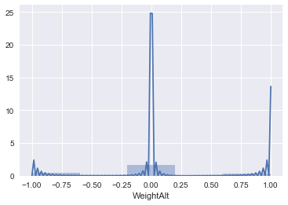

```python
sns.distplot(two_weighings.dropna())
#plt.savefig("twoweighings.pdf")
```

The measurements are all within 1 kg of each other.

Next let's look for unusual value that might indicate errors or other problems.

```python
donkeys.describe()
```

|  | BCS | Length | Girth | Height | Weight | WeightAlt |
| --- | --- | --- | --- | --- | --- | --- |
| count | 544.000000 | 544.000000 | 544.000000 | 544.000000 | 544.000000 | 31.000000 |
| mean | 2.889706 | 95.674632 | 115.946691 | 101.349265 | 152.104779 | 150.258065 |
| std | 0.425656 | 7.348897 | 7.438570 | 4.256430 | 26.506715 | 22.711183 |
| min | 1.000000 | 46.000000 | 66.000000 | 71.000000 | 27.000000 | 98.000000 |
| 25% | 2.500000 | 92.000000 | 112.750000 | 99.000000 | 139.000000 | 141.500000 |
| 50% | 3.000000 | 97.000000 | 117.000000 | 102.000000 | 155.000000 | 151.000000 |
| 75% | 3.000000 | 101.000000 | 121.000000 | 104.000000 | 170.000000 | 165.500000 |
| max | 4.500000 | 112.000000 | 134.000000 | 116.000000 | 230.000000 | 194.000000 |

```python
donkeys.quantile([0.005, 0.995])
```

|  | BCS | Length | Girth | Height | Weight | WeightAlt |
| --- | --- | --- | --- | --- | --- | --- |
| 0.005 | 1.5 | 71.145 | 90.000 | 89.0 | 71.715 | 98.75 |
| 0.995 | 4.0 | 111.000 | 131.285 | 112.0 | 214.000 | 192.80 |

We make a copy of the original data set and name it `donkeys2`.

```python
donkeys2 = donkeys[(donkeys['BCS'] > 1) & (donkeys['BCS'] < 4.5) &
                  (donkeys['Weight'] > 50)].copy()

donkeys2 = donkeys2.reset_index()

y_donkeys2 = donkeys2['Weight']
```

```python
donkeys2.head(10)
```

|  | index | BCS | Age | Sex | Length | Girth | Height | Weight | WeightAlt |
| --- | --- | --- | --- | --- | --- | --- | --- | --- | --- |
| 0 | 0 | 3.0 | <2 | stallion | 78 | 90 | 90 | 77 | NaN |
| 1 | 1 | 2.5 | <2 | stallion | 91 | 97 | 94 | 100 | NaN |
| 2 | 2 | 1.5 | <2 | stallion | 74 | 93 | 95 | 74 | NaN |
| 3 | 3 | 3.0 | <2 | female | 87 | 109 | 96 | 116 | NaN |
| 4 | 4 | 2.5 | <2 | female | 79 | 98 | 91 | 91 | NaN |
| 5 | 5 | 1.5 | <2 | female | 86 | 102 | 98 | 105 | NaN |
| 6 | 6 | 2.5 | <2 | stallion | 83 | 106 | 96 | 108 | NaN |
| 7 | 7 | 2.0 | <2 | stallion | 77 | 95 | 89 | 86 | NaN |
| 8 | 9 | 3.0 | <2 | stallion | 92 | 110 | 99 | 141 | NaN |
| 9 | 10 | 3.0 | <2 | female | 86 | 105 | 92 | 100 | NaN |

## Test-Train split

Before we proceed with our data analysis, we divide the data into an 80% - 20% split and set aside 20% for evaluation of the model.

```python
from sklearn.model_selection import train_test_split

#train, test = train_test_split(donkeys2, test_size=0.2, random_state=1141)
```

```python
indices = np.arange(len(donkeys2))
np.random.shuffle(indices)
n_train = int(np.round((len(donkeys2)*0.8)))
n_test = len(donkeys2) - n_train
```

```python
indices[:n_train]
```

```
array([470, 485, 373, 326,  55, 413, 197, 195, 249, 151, 262, 468, 338,
       228, 525, 455, 424, 371, 290, 110, 407, 421, 426, 127, 454, 344,
       132,  90, 506, 452, 315, 274, 396,  53, 175, 360, 300, 369, 236,
       518, 263, 178, 191, 531, 345, 465, 447, 476, 185, 205, 162, 169,
       204, 339, 500, 271, 478,  99, 351, 536, 335, 186, 218, 147, 159,
       521,  68, 287, 317, 358, 377, 453, 130, 406, 540, 242, 314, 168,
       283, 292, 190, 423, 100, 383, 303, 148, 534, 273,  67,  83, 170,
       357,  33, 451, 203, 462, 208, 416, 507, 361, 321, 207, 502, 418,
       306,  40,  76, 493, 359, 192, 199, 387, 137, 458, 456,  94,  62,
       116, 515, 114, 318, 238,  32,  80, 295, 294, 425,  22, 252,  29,
       117, 189, 355, 427, 448, 144,  51, 106, 432, 411, 311, 135, 112,
       342, 240, 497, 152, 259, 272, 121, 469, 380, 291, 417, 390,  12,
        26, 239, 222,  73,  84, 224, 409, 459, 126,  19, 480, 430, 235,
       438, 233,  10, 141,  31, 265,  89, 181, 378, 270, 284, 299,  37,
       187,  17, 389,  61, 256, 487, 414, 400,  79, 182, 352, 535, 202,
```

[output cut: 19 more lines]

## EDA

We briefly explore the data in the training set.

We examine the categorical variables with boxplots.

We also examine the relationship between explanatory numberic variables.

```python
train = donkeys2.iloc[indices[ :n_train], ]
```

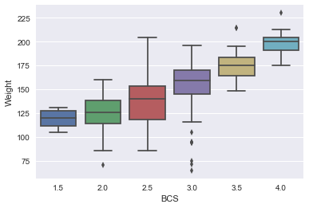

```python
sns.boxplot(x = train['BCS'], y = train['Weight'])
#plt.savefig("bcs_box.pdf")
```

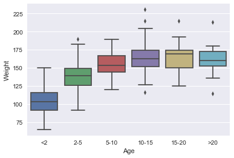

```python
sns.boxplot(x = train['Age'], y = train['Weight'],
            order = ['<2', '2-5', '5-10', '10-15', '15-20', '>20'])
#plt.savefig("age_box.pdf")
```

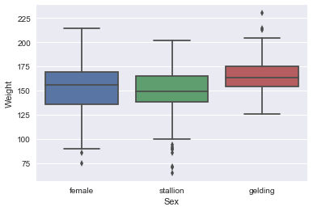

```python
sns.boxplot(x = train['Sex'], y = train['Weight'], order = ['female', 'stallion', 'gelding'])
#plt.savefig("sex_box.pdf")
```

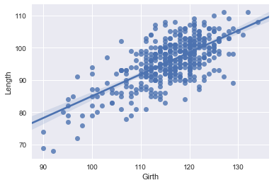

```python
sns.regplot('Girth', 'Length', train)
#plt.savefig('girth_length.pdf')
```

Observations:

- Age distribution looks similar for donkeys over 5
- Doesn't appear to be much of a difference in weight for different sexes
- Median weight increase with BCS, but not linearly. (BCS is ordinal, not numeric)

## Starting point for a model

We can think of a donkey as a cylinder with appendages. This leads to the mass of the donkey being proportion to a product of the girth and length. This implies a model for log(weight) that is linear in log of girth and length, i.e., $\log(weight) = \alpha + \beta \log(length) + \gamma \log(girth)$.

Milner and Rougier broaden the starting point to consider models of the form:

$$ h_\lambda(weight) = X\theta$$

where $h_\lambda(y) = \frac {y^\lambda - 1}{\lambda}$ for $\lambda \neq 0$ and $h_\lambda(y) = log(y)$ for $\lambda = 0$ And where $X$ has 8 possible forms according to whether each of the three variables log(`girth`), log(`height`) or log(`length`) is included.

### Transform the response variables

All of these models use the log-transformed values for `Length`, `Height`, and `Girth`. We add their transformed variables to our design matrix.

```python
donkeys2['Length_log'] = np.log(donkeys2['Length'])
donkeys2['Height_log'] = np.log(donkeys2['Height'])
donkeys2['Girth_log'] = np.log(donkeys2['Girth'])
```

## Choosing the loss function

We develop our own loss function to reflect the cost to the donkey's health of an incorrect dose. In particular for anesthetics, we want to err on the side of under dosing because it can be dangerous to over dose and the effects of the drug can be observed, meaning that if the donkey is still in pain then the dose can be increased.

For this reason, we design our own aneshtetic loss function:

```python
def an_loss(x):
    wt = (x >= 0) + 3 * (x < 0)
    return np.square(x) * wt
```

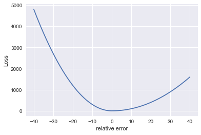

```python
xs = np.linspace(-40, 40, 500)
loss = an_loss(xs)
plt.plot(xs, loss, label="Modified Quadratic Loss")
plt.xlabel(r"relative error")
plt.ylabel(r"Loss")
plt.savefig("l1mod_plt.pdf")
```

Notice that the loss function is expressed in terms of relative error. $$ \frac {y - \hat{y}} {\hat{y}}$$ A negative loss indicate an overdose.

## Model Selection

We want to fit the best model where we choose the transformation for $y$ and the best subset of the three quantitative variables, `girth`, `length` and `height`. To do this, we fit the 7 possible models (all combinations of the subsets of the three variables) for each $\lambda$. We use our special loss function in the optimization.

### Choosing the Box-Cox transformation

We set up a few possible $\lambda$ values, keeping to values that are easily interpretable.

```python
lmbdas = [-1., -0.75, -0.667, -0.5, -0.333, 0, 0.333, 0.5, 0.667, 0.75, 1, 1.5, 2]
len(lmbdas)
```

```
13
```

We import the `stats` library which has a Box-Cox tranformation.

```python
from scipy import stats
from scipy.stats import boxcox
```

We will find it useful to have the inverse of the Box-Cox transformation so that we can compare the predicted values in he original units. We write our own.

```python
def invboxcox(y, ld):
    if ld == 0:
        return np.exp(y)
    else:
        y2 = np.where(y > 0, y, 0.0)
        return ((ld*y2)+1)**(1/ld)
```

We import `minimize` in order to optimize with our special loass function.

```python
# import the optimize library
from scipy.optimize import minimize
```

In the optimization we want to use the relative error so we revise define a new loss function that incorporates our original loss function.

```python
# Update the loss function to compute relative loss
def new_loss(theta, X, y):
    yhat = X @ theta
    return np.mean(an_loss((y - yhat) / yhat))
```

First, we examine therelationship between the transformed weight and log girth.

```python
train = donkeys2.iloc[indices[ :n_train], ]
y_orig = train["Weight"]
y_boxcox = boxcox(y_orig, lmbda = lmbdas[7])
```

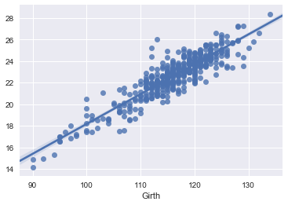

```python
sns.regplot(x = train['Girth'], y = y_boxcox)
#plt.savefig('girth_length.pdf')
```

```python
X = train[['Girth_log', 'Height_log']]
X_1 = np.hstack([X.values, np.ones((len(X), 1))])

res = minimize(lambda theta: new_loss(theta, X_1, y_boxcox), np.ones(3))

theta_est = res['x']
y_pred = X_1 @ theta_est
y_hat = invboxcox(y_pred, lmbdas[7])

100* np.sqrt(np.mean(an_loss((y_orig - y_hat)/ y_hat)))
#np.sqrt(np.mean((an_loss((y_orig - y_hat)/ y_hat))))
```

```
9.3448136526278045
```

```python
100 * np.sqrt(np.mean(an_loss((y_boxcox - y_pred)/ y_pred)))
```

```
5.0482349961037789
```

Investigate the fit by examing the residuals

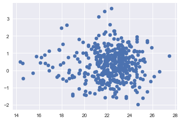

```python
resids = y_boxcox - y_pred
plt.scatter(y_pred, resids)
```

Now, we're ready to fit all of the possible models.

To iterate over all possible combinations of explanatory variables and lambdas. We generate the combinations of explanatory variables.

```python
import itertools

models = []
response_vars = ['Girth_log', 'Length_log', 'Height_log']

for L in range(1, len(response_vars)+1):
  for subset in itertools.combinations(response_vars, L):
    models.append(list(subset))

models
```

```
[['Girth_log'],
 ['Length_log'],
 ['Height_log'],
 ['Girth_log', 'Length_log'],
 ['Girth_log', 'Height_log'],
 ['Length_log', 'Height_log'],
 ['Girth_log', 'Length_log', 'Height_log']]
```

```python
rmse_mods = []

for a_mod in models:
    rmse = []
    for lmbda in lmbdas:
        y_boxcox = boxcox(y_orig, lmbda = lmbda)
        X = train[a_mod]
        X_1 = np.hstack([X.values, np.ones((len(X), 1))])
        res = minimize(lambda theta: new_loss(theta, X_1, y_boxcox), np.ones(len(a_mod)+1))
        theta_est = res['x']
        y_pred = X_1 @ theta_est
        y_hat= invboxcox(X_1 @ theta_est, lmbda)
        #        rmse.append(100*np.sqrt(np.mean(((y_orig - y_hat)/ y_hat)**2)))
        rmse.append(100*np.std((y_orig - y_hat)/ y_hat))
    rmse_mods.append(rmse)
```

```python
rmse_mods[3]
```

```
[7.395140637258686,
 6.988521226680097,
 6.883213591489948,
 6.700585917659599,
 6.557115443759722,
 6.374250754822134,
 6.325965463543044,
 6.363821583656327,
 6.443983676461884,
 6.5031026936640925,
 6.749914532883333,
 16.365937201083206,
 16.4013157440236]
```

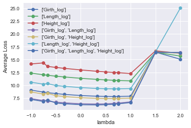

```python
for i in range(0, 7):
    plt.plot(lmbdas, rmse_mods[i], "-o", label = models[i])

plt.xlabel(r"lambda")
plt.ylabel("Average Loss")
plt.legend(loc = "best")
plt.savefig("lossFunction6.pdf")
```

The three-variable model has slightly smaller error than the girth-length model. We will stick with the two-variable model as there is little gain from the additional variable.

## Transforming Categorical Variables

Next we transform the categorical variables into dummy variables so that we can include them in the model.

```python
donkeys2 = pd.get_dummies(donkeys2, columns=["BCS", "Age", "Sex"])
```

```python
donkeys2.head()
```

|  | index | Length | Girth | Height | Weight | WeightAlt | Length_log | Height_log | Girth_log | BCS_1.5 | ... | BCS_4.0 | Age_10-15 | Age_15-20 | Age_2-5 | Age_5-10 | Age_<2 | Age_>20 | Sex_female | Sex_gelding | Sex_stallion |
| --- | --- | --- | --- | --- | --- | --- | --- | --- | --- | --- | --- | --- | --- | --- | --- | --- | --- | --- | --- | --- | --- |
| 0 | 0 | 78 | 90 | 90 | 77 | NaN | 4.356709 | 4.499810 | 4.499810 | 0 | ... | 0 | 0 | 0 | 0 | 0 | 1 | 0 | 0 | 0 | 1 |
| 1 | 1 | 91 | 97 | 94 | 100 | NaN | 4.510860 | 4.543295 | 4.574711 | 0 | ... | 0 | 0 | 0 | 0 | 0 | 1 | 0 | 0 | 0 | 1 |
| 2 | 2 | 74 | 93 | 95 | 74 | NaN | 4.304065 | 4.553877 | 4.532599 | 1 | ... | 0 | 0 | 0 | 0 | 0 | 1 | 0 | 0 | 0 | 1 |
| 3 | 3 | 87 | 109 | 96 | 116 | NaN | 4.465908 | 4.564348 | 4.691348 | 0 | ... | 0 | 0 | 0 | 0 | 0 | 1 | 0 | 1 | 0 | 0 |
| 4 | 4 | 79 | 98 | 91 | 91 | NaN | 4.369448 | 4.510860 | 4.584967 | 0 | ... | 0 | 0 | 0 | 0 | 0 | 1 | 0 | 1 | 0 | 0 |

5 rows × 24 columns

Drop the variables that we are not using: 'Length" and 'WeightAlt'. Also drop one category from 'Sex', 'BCS' and 'Age' dummies so that the matrix is not over paramterized.

```python
donkeys2 = donkeys2.drop(['index', 'Height',  'Length', 'Girth', 'Weight',
                          'Height_log', 'WeightAlt',
                          'BCS_3.0', 'Age_5-10', 'Sex_female'],
                         axis = 1)
```

```python
donkeys2.head(10)
```

|  | Length_log | Girth_log | BCS_1.5 | BCS_2.0 | BCS_2.5 | BCS_3.5 | BCS_4.0 | Age_10-15 | Age_15-20 | Age_2-5 | Age_<2 | Age_>20 | Sex_gelding | Sex_stallion |
| --- | --- | --- | --- | --- | --- | --- | --- | --- | --- | --- | --- | --- | --- | --- |
| 0 | 4.356709 | 4.499810 | 0 | 0 | 0 | 0 | 0 | 0 | 0 | 0 | 1 | 0 | 0 | 1 |
| 1 | 4.510860 | 4.574711 | 0 | 0 | 1 | 0 | 0 | 0 | 0 | 0 | 1 | 0 | 0 | 1 |
| 2 | 4.304065 | 4.532599 | 1 | 0 | 0 | 0 | 0 | 0 | 0 | 0 | 1 | 0 | 0 | 1 |
| 3 | 4.465908 | 4.691348 | 0 | 0 | 0 | 0 | 0 | 0 | 0 | 0 | 1 | 0 | 0 | 0 |
| 4 | 4.369448 | 4.584967 | 0 | 0 | 1 | 0 | 0 | 0 | 0 | 0 | 1 | 0 | 0 | 0 |
| 5 | 4.454347 | 4.624973 | 1 | 0 | 0 | 0 | 0 | 0 | 0 | 0 | 1 | 0 | 0 | 0 |
| 6 | 4.418841 | 4.663439 | 0 | 0 | 1 | 0 | 0 | 0 | 0 | 0 | 1 | 0 | 0 | 1 |
| 7 | 4.343805 | 4.553877 | 0 | 1 | 0 | 0 | 0 | 0 | 0 | 0 | 1 | 0 | 0 | 1 |
| 8 | 4.521789 | 4.700480 | 0 | 0 | 0 | 0 | 0 | 0 | 0 | 0 | 1 | 0 | 0 | 1 |
| 9 | 4.454347 | 4.653960 | 0 | 0 | 0 | 0 | 0 | 0 | 0 | 0 | 1 | 0 | 0 | 0 |

```python
train = donkeys2.iloc[indices[:n_train], ]
y_train = y_donkeys2[indices[ :n_train]]
print("length of train", len(train))

y_train.head(10)
```

```
length of train 433
```

```
470    173
485    159
373    141
326    164
55     133
413    178
197    140
195    155
249    150
151    161
Name: Weight, dtype: int64
```

```python
X_1 = np.hstack([train.values, np.ones((len(train), 1))])
y_boxcox = boxcox(y_train, 0)
```

```python
res = minimize(lambda theta: new_loss(theta, X_1, y_boxcox), np.ones(X_1.shape[1]))
```

```python
theta_est = res['x']
theta_est
```

```
array([  7.45183531e-01,   1.66556953e+00,  -6.61834833e-02,
        -4.60638157e-02,  -2.13313745e-02,   3.79782685e-02,
         7.92848480e-02,   1.05003285e-03,   9.91633699e-03,
        -2.46686048e-02,  -7.94213108e-02,   4.27731276e-03,
         8.53325462e-03,   1.91415499e-02,  -6.32111957e+00])
```

```python
y_pred = X_1 @ theta_est
y_pred[:10]
```

```
array([ 5.15811189,  5.02990018,  4.90585761,  5.03273335,  4.94895807,
        5.15650369,  4.87241177,  5.04501052,  5.04867573,  5.01872866])
```

Let's examine the coefficients for the dummy variables to determine whether we want to keep them in the model or if we want to collapse into fewer categories.

```python
theta_est[[2, 3, 4, 5, 6, 10,9, 7, 8, 11, 12, 13]]
```

```
array([-0.06618348, -0.04606382, -0.02133137,  0.03797827,  0.07928485,
       -0.07942131, -0.0246686 ,  0.00105003,  0.00991634,  0.00427731,
        0.00853325,  0.01914155])
```

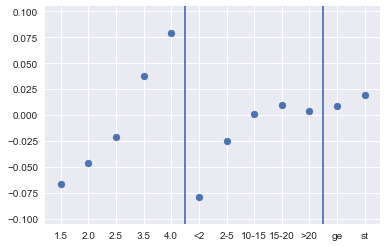

```python
labels = ['1.5','2.0','2.5','3.5','4.0','<2','2-5', '10-15','15-20','>20', 'ge', 'st']

plt.scatter(x = range(12),
            y = theta_est[[2, 3, 4, 5, 6, 10,9, 7, 8, 11, 12, 13]])

plt.xticks(range(12), labels)
plt.axvline(x=4.5)
plt.axvline(x = 9.5)
```

The plot of coefficients above indicates that we could collapse the age catgories into 3: under 2, 2 to 5, and over 5. We also see that the coefficients for the sex dummies are close to 0 so we won't lose much if we drop the sex variable from the model. Ideally we would want to compare the size of these coefficients to their standard errors, but we won't do that here.

## Final Model

We can drop all of the sex dummies. We can also drop the dummies for age over 10 and then the base age category will be for age over 5.

```python
donkeys2 = donkeys2.drop(['Age_10-15', 'Age_15-20', 'Age_>20',
                          'Sex_gelding', 'Sex_stallion'],
                        axis = 1)
```

```python
train = donkeys2.iloc[indices[:n_train], ]
```

Fit the new model to the training set.

```python
X_1 = np.hstack([train.values, np.ones((len(train), 1))])
res = minimize(lambda theta: new_loss(theta, X_1, y_boxcox), np.ones(X_1.shape[1]))
```

```python
theta_est = res['x']
theta_est
```

```
array([ 0.72369783,  1.65854789, -0.06226638, -0.04044221, -0.02232754,
        0.03867827,  0.08235653, -0.02728433, -0.08640164, -6.17902583])
```

## Evaluate the model

Finally, we use the fitted model to predict the weights for those donkeys in the test set. First, we get the test set

```python
test_set = donkeys2.iloc[indices[n_train:], ]
y_test = y_donkeys2[indices[n_train:]]
print("length of test", len(test))

X_test_1 = np.hstack([test_set.values, np.ones((len(test_set), 1))])
y_boxcox_test = boxcox(y_test, 0)
```

[output not shown]

Now we estimate the transformed weight from the model fitted to the training data, and we convert the predicted values into original units.

```python
y_test_pred = X_test_1 @ theta_est
y_test_pred_o = invboxcox(y_test_pred, 0)
```

The following plot shows the typical errors. The red lines correspond to plus/minus 10% of the predicted weight.

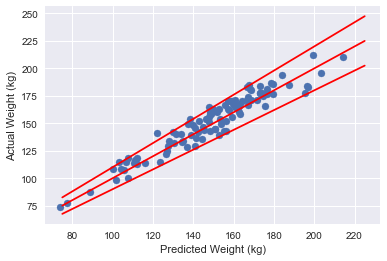

```python
plt.scatter(y_test_pred_o, y_test)
plt.plot([75, 225], [75, 225], 'k-', color = 'r')
plt.plot([75, 225], [82.5, 247.5], 'k-', color="red")
plt.plot([75, 225], [67.5, 202.5], 'k-', color="red")
plt.xlabel("Predicted Weight (kg)")
plt.ylabel("Actual Weight (kg)")
plt.savefig("model_assess.pdf")
```

Nearly all the predicted weights are within 10% of the actual weights. Below we calculate the percentage that are within 10%.

```python
100* np.sum(np.abs((y_test - y_test_pred_o )/y_test_pred_o) < 0.1) / len(y_test)
```

```
95.370370370370367
```